## Tabla de contenidos

**Análisis exploratorio de GPs de la F1**  
Este notebook explora y analiza los datos de vueltas de Fórmula 1 desde 2023 en adelante. Se estudian variables clave como tiempos de vuelta, compuestos de neumáticos, pilotos y tipos de sesión, con el objetivo de identificar patrones, outliers y tendencias relevantes para el rendimiento y la estrategia en la máxima categoría del automovilismo. El análisis incluye limpieza, transformación y visualización de datos, facilitando la comparación entre diferentes años, circuitos y condiciones de carrera.

```python
import pandas as pd

import matplotlib.pyplot as plt

import seaborn as sns
sns.set_style('whitegrid')

from sklearn.preprocessing import MinMaxScaler
```

# RAW DATASET

```python
df_laps = pd.read_csv('../data/laps_since_2023_raw.csv')

df_laps.columns = ['time', 'driver', 'lap_time', 'lap_number', 'stint', 'compound', 'event_name_region', 'event_date', 'session_type_short', 'year']

print(df_laps.shape)
df_laps.head()
```

```
(152162, 10)
```

|  | time | driver | lap_time | lap_number | stint | compound | event_name_region | event_date | session_type_short | year |
| --- | --- | --- | --- | --- | --- | --- | --- | --- | --- | --- |
| 0 | 0 days 00:21:14.563000 | VER | NaN | 1.0 | 1.0 | MEDIUM | Bahrain | 2023-03-05 | FP1 | 2023 |
| 1 | 0 days 00:22:49.992000 | VER | 0 days 00:01:35.429000 | 2.0 | 1.0 | MEDIUM | Bahrain | 2023-03-05 | FP1 | 2023 |
| 2 | 0 days 00:25:33.677000 | VER | NaN | 3.0 | 1.0 | MEDIUM | Bahrain | 2023-03-05 | FP1 | 2023 |
| 3 | 0 days 00:28:19.697000 | VER | NaN | 4.0 | 2.0 | MEDIUM | Bahrain | 2023-03-05 | FP1 | 2023 |
| 4 | 0 days 00:30:13.359000 | VER | 0 days 00:01:53.662000 | 5.0 | 2.0 | MEDIUM | Bahrain | 2023-03-05 | FP1 | 2023 |

```python
df_laps.isna().sum() / df_laps.shape[0] * 100
```

```
time                   0.000000
driver                 0.000000
lap_time              13.839855
lap_number             0.000000
stint                  0.322025
compound               0.322025
event_name_region      0.000000
event_date             0.000000
session_type_short     0.000000
year                   0.000000
dtype: float64
```

Existe aproximadamente un 14% de valores nulos en la columna `lap_time`. Por simplicidad, no se imputarán estos valores; únicamente se filtrarán.

```python
df_laps[~df_laps.lap_time.isna()].isna().sum() / df_laps[~df_laps.lap_time.isna()].shape[0] * 100
```

```
time                  0.00000
driver                0.00000
lap_time              0.00000
lap_number            0.00000
stint                 0.35392
compound              0.35392
event_name_region     0.00000
event_date            0.00000
session_type_short    0.00000
year                  0.00000
dtype: float64
```

A pesar de filtrar los registros con valores nulos únicamente en `lap_time`, las columnas `stint` y `compound` continúan presentando aproximadamente el mismo porcentaje de valores nulos. Por ello, se decide aplicar `dropna()` para eliminar todas las filas que contengan valores faltantes en estas columnas y asegurar la calidad de los datos para el análisis posterior.

```python
df_laps.dropna(inplace=True)
df_laps.reset_index(drop=True, inplace=True)
```

```python
df_laps.info()
```

```
<class 'pandas.core.frame.DataFrame'>
RangeIndex: 130639 entries, 0 to 130638
Data columns (total 10 columns):
 #   Column              Non-Null Count   Dtype
---  ------              --------------   -----
 0   time                130639 non-null  object
 1   driver              130639 non-null  object
 2   lap_time            130639 non-null  object
 3   lap_number          130639 non-null  float64
 4   stint               130639 non-null  float64
 5   compound            130639 non-null  object
 6   event_name_region   130639 non-null  object
 7   event_date          130639 non-null  object
 8   session_type_short  130639 non-null  object
 9   year                130639 non-null  int64
dtypes: float64(2), int64(1), object(7)
memory usage: 10.0+ MB
```

```python
df_laps['time'] = pd.to_timedelta(df_laps['time'])
df_laps['lap_time'] = pd.to_timedelta(df_laps['lap_time'])
df_laps['lap_number'] = df_laps['lap_number'].astype('int32')
df_laps['stint'] = df_laps['stint'].astype('int32')
```

```python
df_laps.info()
```

```
<class 'pandas.core.frame.DataFrame'>
RangeIndex: 130639 entries, 0 to 130638
Data columns (total 10 columns):
 #   Column              Non-Null Count   Dtype
---  ------              --------------   -----
 0   time                130639 non-null  timedelta64[ns]
 1   driver              130639 non-null  object
 2   lap_time            130639 non-null  timedelta64[ns]
 3   lap_number          130639 non-null  int32
 4   stint               130639 non-null  int32
 5   compound            130639 non-null  object
 6   event_name_region   130639 non-null  object
 7   event_date          130639 non-null  object
 8   session_type_short  130639 non-null  object
 9   year                130639 non-null  int64
dtypes: int32(2), int64(1), object(5), timedelta64[ns](2)
memory usage: 9.0+ MB
```

# EDA

## VARIABLES CATEGÓRICAS

### ▶️ driver

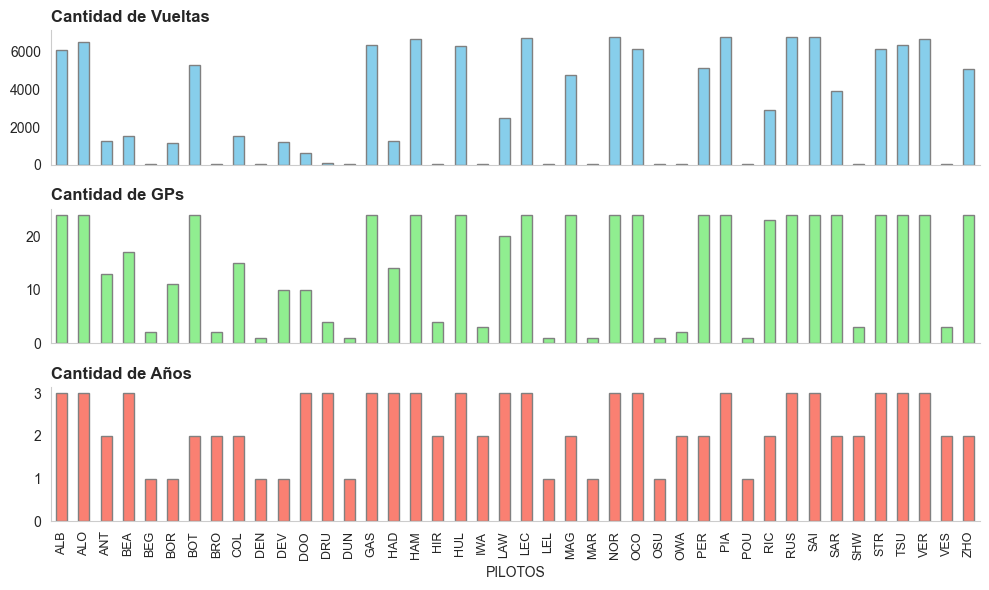

```python
plt.figure(figsize=(10, 6))

plt.subplot(3, 1, 1)
df_laps.driver.value_counts().sort_index().plot(kind='bar', color='skyblue', edgecolor='gray')
plt.title('Cantidad de Vueltas', loc='left', fontweight='bold')
plt.xlabel('')
plt.xticks([])
plt.grid(False)

plt.subplot(3, 1, 2)
df_laps.groupby('driver')['event_name_region'].nunique().sort_index().plot(kind='bar', color='lightgreen', edgecolor='gray')
plt.title('Cantidad de GPs', loc='left', fontweight='bold')
plt.xlabel('')
plt.xticks([])
plt.grid(False)

plt.subplot(3, 1, 3)
df_laps.groupby('driver')['year'].nunique().sort_index().plot(kind='bar', color='salmon', edgecolor='gray')
plt.title('Cantidad de Años', loc='left', fontweight='bold')
plt.xlabel('PILOTOS')
plt.grid(False)
plt.xticks(fontsize=9)
sns.despine(top=True)

plt.tight_layout()
plt.show()
```

La distribución de vueltas por piloto es desigual, ya que algunos son veteranos con mayor participación, mientras que otros son rookies o pilotos de reserva que solo completan algunas vueltas durante las prácticas. Por ello, es recomendable añadir una columna que clasifique a los pilotos en veteranos, rookies y reserva para facilitar el análisis.

`Además, sería útil calcular para cada piloto el tiempo transcurrido desde su última carrera (por ejemplo, en días, semanas o meses), lo que permitiría identificar a aquellos que han estado inactivos recientemente o que han regresado tras una ausencia prolongada.`

### ▶️ compound

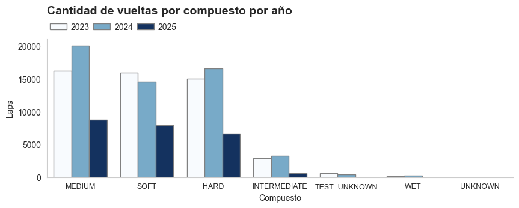

```python
plt.figure(figsize=(10, 3))

sns.countplot(data=df_laps, x='compound', hue='year', palette='Blues', edgecolor='gray', order=df_laps.compound.value_counts().index)
plt.title('Cantidad de vueltas por compuesto por año', loc='left', fontsize=14, fontweight='bold', pad=30)
plt.xticks(fontsize=9)
plt.xlabel('Compuesto')
plt.ylabel('Laps')
plt.grid(False)
sns.despine(top=True)
plt.legend(title='', loc='upper left', bbox_to_anchor=(-0.01, 1.17), ncol=len(df_laps['year'].unique()), frameon=False, handletextpad=0.5, columnspacing=0.5)

plt.show()
```

Existen compuestos experimentales denotados como UNKNOWN y TEST_UNKNOWN. Es importante explorar en detalle su uso: ¿se emplearon durante toda una sesión o solo por algunos minutos? Dependiendo de los hallazgos, podría ser recomendable descartar esas sesiones o incluso el Gran Premio completo para evitar sesgos en el análisis.

### ▶️ event_name_region

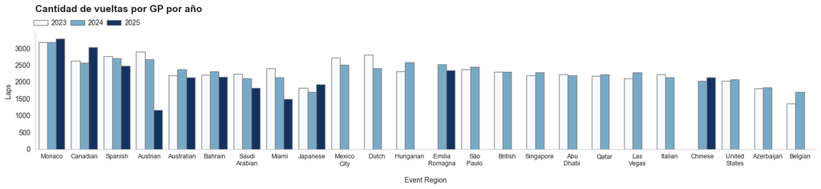

```python
plt.figure(figsize=(20, 3))

sns.countplot(data=df_laps, x='event_name_region', hue='year', palette='Blues', edgecolor='gray', order=df_laps.event_name_region.value_counts().index)
plt.title('Cantidad de vueltas por GP por año', loc='left', fontsize=14, fontweight='bold', pad=30)
plt.xlabel('Event Region')
plt.xticks(ticks=plt.xticks()[0], labels=[ _.get_text().replace(' ', '\n') for _ in plt.gca().get_xticklabels() ], fontsize=9)
plt.ylabel('Laps')
plt.grid(False)
sns.despine(top=True)

plt.legend(title='', loc='upper left', bbox_to_anchor=(-0.01, 1.17), ncol=len(df_laps['year'].unique()), frameon=False, handletextpad=0.5, columnspacing=0.5)

plt.show()
```

### ▶️ session_type_short

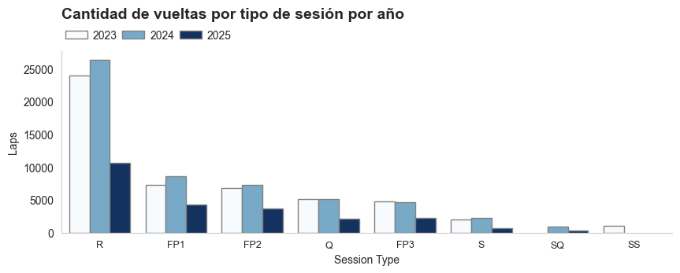

```python
plt.figure(figsize=(10, 3))

sns.countplot(data=df_laps, x='session_type_short', hue='year', palette='Blues', edgecolor='gray', order=df_laps.session_type_short.value_counts().index)
plt.title('Cantidad de vueltas por tipo de sesión por año', loc='left', fontsize=14, fontweight='bold', pad=30)
plt.xlabel('Session Type')
plt.xticks(ticks=plt.xticks()[0], labels=[ _.get_text().replace(' ', '\n') for _ in plt.gca().get_xticklabels() ], fontsize=9)
plt.ylabel('Laps')
plt.grid(False)
sns.despine(top=True)

plt.legend(title='', loc='upper left', bbox_to_anchor=(-0.01, 1.17), ncol=len(df_laps['year'].unique()), frameon=False, handletextpad=0.5, columnspacing=0.5)

plt.show()
```

### ▶️ year

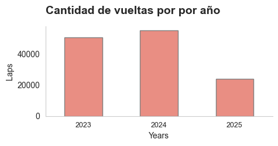

```python
plt.figure(figsize=(5, 2))

sns.countplot(data=df_laps, x='year', color='Salmon', edgecolor='gray', width=0.5)
plt.title('Cantidad de vueltas por por año', loc='left', fontsize=14, fontweight='bold', pad=15)
plt.xlabel('Years')
plt.xticks(fontsize=9)
plt.ylabel('Laps')
plt.grid(False)
sns.despine(top=True)

plt.show()
```

## VARIABLES NUMÉRICAS

### ▶️ time / time_minutes

```python
df_laps.time.describe()
```

```
count                       130111
mean     0 days 01:17:17.413683224
std      0 days 00:38:22.701504370
min                0 days 00:00:00
25%         0 days 00:48:41.183000
50%         0 days 01:11:48.588000
75%         0 days 01:44:29.056500
max         0 days 03:27:05.468000
Name: time, dtype: object
```

Se observa que la duración máxima para una sesión fue de más de 3 horas, lo cual probablemente se deba a la presencia de lluvia o interrupciones prolongadas. Este tipo de situaciones puede afectar la distribución de los tiempos y la cantidad de vueltas completadas, por lo que es importante tenerlo en cuenta al analizar los datos.

Por simplicidad se transforma a minutos.

```python
df_laps['time_minutes'] = pd.to_timedelta(df_laps['time']).dt.total_seconds() // 60
```

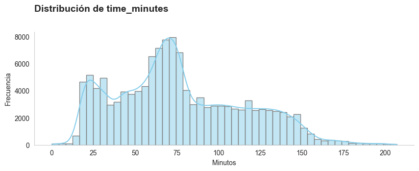

```python
plt.figure(figsize=(10, 3))

sns.histplot(df_laps['time_minutes'], bins=50, color='skyblue', edgecolor='gray', kde=True)
plt.title('Distribución de time_minutes', loc='left', fontsize=14, fontweight='bold', pad=30)
plt.xlabel('Minutos')
plt.xticks(ticks=range(0, int(df_laps['time_minutes'].max()) + 1, 25))
plt.ylabel('Frecuencia')
plt.grid(False)
sns.despine(top=True)

plt.show()
```

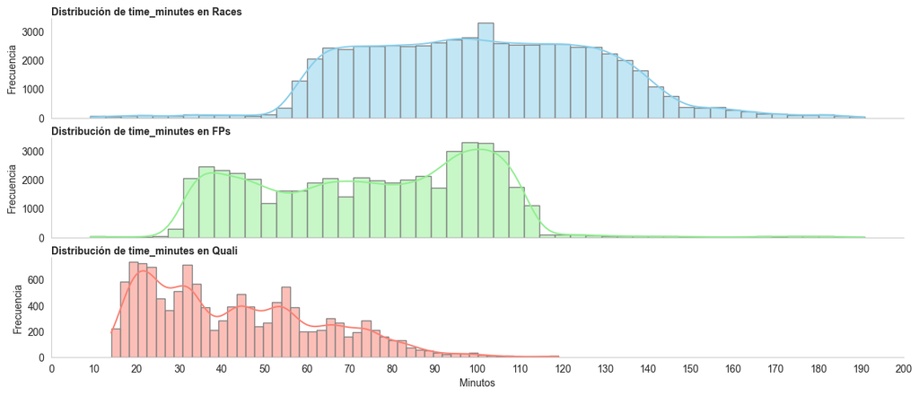

```python
plt.figure(figsize=(15, 6))

plt.subplot(3, 1, 1)
sns.histplot(df_laps.query('session_type_short == "R"')['time_minutes'], bins=50, color='skyblue', edgecolor='gray', kde=True)
plt.title('Distribución de time_minutes en Races', loc='left', fontsize=10, fontweight='bold', pad=3)
plt.xlabel('')
plt.xticks([])
plt.ylabel('Frecuencia')
plt.grid(False)
sns.despine(top=True)

plt.subplot(3, 1, 2)
sns.histplot(df_laps.query('session_type_short.isin(["FP1", "FP2", "FP3"])')['time_minutes'], bins=50, color='lightgreen', edgecolor='gray', kde=True)
plt.title('Distribución de time_minutes en FPs', loc='left', fontsize=10, fontweight='bold', pad=3)
plt.xlabel('')
plt.xticks([])
plt.ylabel('Frecuencia')
plt.grid(False)
sns.despine(top=True)

plt.subplot(3, 1, 3)
sns.histplot(df_laps.query('session_type_short.isin(["Q"])')['time_minutes'], bins=50, color='salmon', edgecolor='gray', kde=True)
plt.title('Distribución de time_minutes en Quali', loc='left', fontsize=10, fontweight='bold', pad=3)
plt.xlabel('Minutos')
plt.xticks(ticks=range(0, int(df_laps['time_minutes'].max()) + 1, 10))
plt.ylabel('Frecuencia')
plt.grid(False)
sns.despine(top=True)

plt.show()
```

### ▶️ lap_time / lap_time_seconds

```python
df_laps.lap_time.describe()
```

```
count                       130111
mean     0 days 00:01:35.745916171
std      0 days 00:00:31.915952597
min         0 days 00:01:04.314000
25%         0 days 00:01:21.883000
50%         0 days 00:01:32.848000
75%         0 days 00:01:43.061500
max         0 days 00:42:06.253000
Name: lap_time, dtype: object
```

```python
df_laps['lap_time_seconds'] = pd.to_timedelta(df_laps['lap_time']).dt.total_seconds()
```

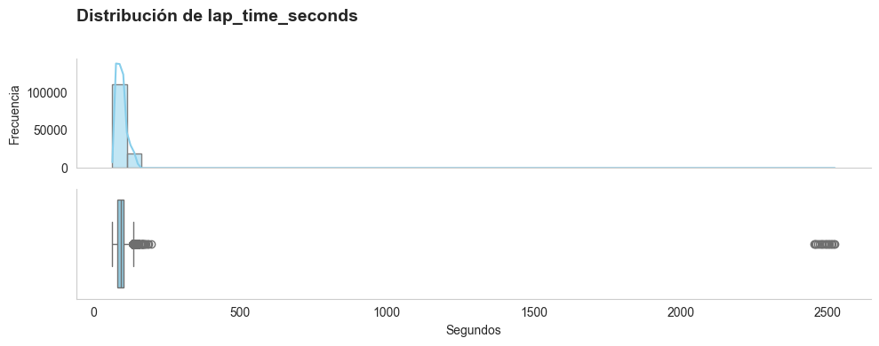

```python
plt.figure(figsize=(10, 4))

# Histograma
plt.subplot(2, 1, 1)
sns.histplot(df_laps['lap_time_seconds'], bins=50, color='skyblue', edgecolor='gray', kde=True)
plt.title('Distribución de lap_time_seconds', loc='left', fontsize=14, fontweight='bold', pad=30)
plt.xlabel('')
plt.xticks([])
plt.ylabel('Frecuencia')
plt.grid(False)
sns.despine(top=True)

# Boxplot
plt.subplot(2, 1, 2)
sns.boxplot(x=df_laps['lap_time_seconds'], color='skyblue')
plt.xlabel('Segundos')
plt.ylabel('')
plt.grid(False)
sns.despine(top=True)

plt.tight_layout()
plt.show()
```

```python
# Detección de outliers en la columna 'lap_time_seconds' usando el método IQR
Q1 = df_laps['lap_time_seconds'].quantile(0.25)
Q3 = df_laps['lap_time_seconds'].quantile(0.75)
IQR = Q3 - Q1

lower_bound = Q1 - 1.5 * IQR
upper_bound = Q3 + 1.5 * IQR

# Marca los outliers en una nueva columna booleana
df_laps['flag_lap_time_outlier'] = (df_laps['lap_time_seconds'] > upper_bound)
```

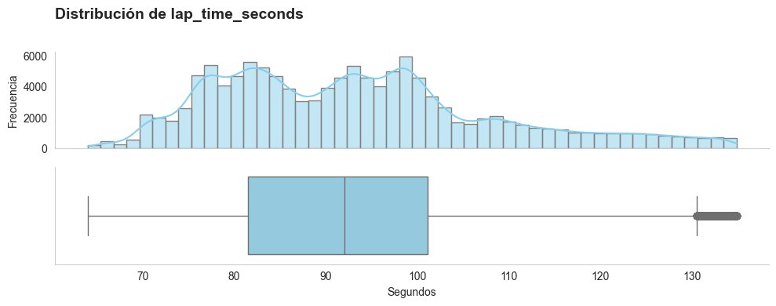

```python
plt.figure(figsize=(10, 4))

# Histograma
plt.subplot(2, 1, 1)
sns.histplot(df_laps.query('flag_lap_time_outlier == False')['lap_time_seconds'], bins=50, color='skyblue', edgecolor='gray', kde=True)
plt.title('Distribución de lap_time_seconds', loc='left', fontsize=14, fontweight='bold', pad=30)
plt.xlabel('')
plt.xticks([])
plt.ylabel('Frecuencia')
plt.grid(False)
sns.despine(top=True)

# Boxplot
plt.subplot(2, 1, 2)
sns.boxplot(x=df_laps.query('flag_lap_time_outlier == False')['lap_time_seconds'], color='skyblue')
plt.xlabel('Segundos')
plt.ylabel('')
plt.grid(False)
sns.despine(top=True)

plt.tight_layout()
plt.show()
```

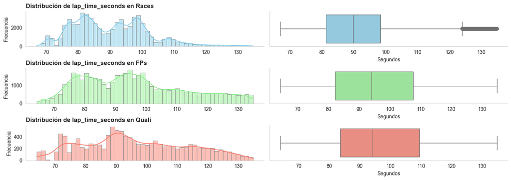

```python
fig, axes = plt.subplots(3, 2, figsize=(14, 5))

session_types = [
    ('R', 'Races', 'skyblue'),
    (['FP1', 'FP2', 'FP3'], 'FPs', 'lightgreen'),
    ('Q', 'Quali', 'salmon')
]

for i, (stype, title, color) in enumerate(session_types):
    data = df_laps.query('flag_lap_time_outlier == False')
    if isinstance(stype, list):
        data = data[data['session_type_short'].isin(stype)]
    else:
        data = data[data['session_type_short'] == stype]

    # Histograma
    sns.histplot(data['lap_time_seconds'], bins=50, color=color, edgecolor='gray', kde=True, ax=axes[i, 0])
    axes[i, 0].set_title(f'Distribución de lap_time_seconds en {title}', loc='left', fontsize=12, fontweight='bold')
    axes[i, 0].set_xlabel('')
    axes[i, 0].set_ylabel('Frecuencia')
    axes[i, 0].grid(False)
    sns.despine(ax=axes[i, 0], top=True)

    # Boxplot
    sns.boxplot(x=data['lap_time_seconds'], color=color, ax=axes[i, 1])
    axes[i, 1].set_xlabel('Segundos')
    axes[i, 1].set_ylabel('')
    axes[i, 1].grid(False)
    sns.despine(ax=axes[i, 1], top=True)

plt.tight_layout()
plt.show()
```

```python
from sklearn.preprocessing import MinMaxScaler

# Escalar lap_time_seconds por year, event_name_region y session_type_short usando MinMaxScaler
df_laps['lap_time_seconds_normalized'] = (
    df_laps.groupby(['year', 'event_name_region', 'session_type_short'])['lap_time_seconds']
    .transform(lambda x: MinMaxScaler().fit_transform(x.values.reshape(-1, 1)).flatten())
)
```

La normalización de `lap_time` es fundamental para comparar tiempos de vuelta entre diferentes años, circuitos y tipos de sesión. Cada combinación de estos factores puede tener condiciones únicas (longitud de pista, clima, reglamento, etc.) que afectan los valores absolutos de los tiempos. Al normalizar, transformamos los tiempos a una escala común (por ejemplo, entre 0 y 1), lo que permite analizar patrones, identificar outliers y comparar desempeños relativos sin que las diferencias estructurales distorsionen el análisis. Así, se facilita la detección de tendencias y anomalías que serían difíciles de observar usando los valores originales.

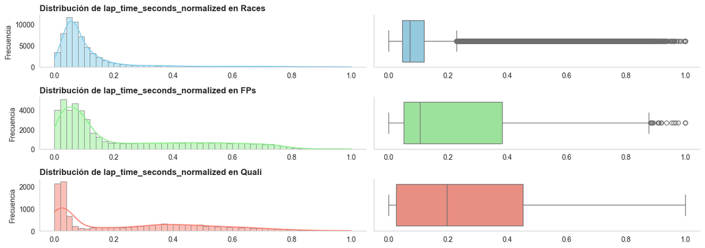

```python
fig, axes = plt.subplots(3, 2, figsize=(14, 5))

session_types = [
    ('R', 'Races', 'skyblue'),
    (['FP1', 'FP2', 'FP3'], 'FPs', 'lightgreen'),
    ('Q', 'Quali', 'salmon')
]

for i, (stype, title, color) in enumerate(session_types):
    data = df_laps.query('flag_lap_time_outlier == False')
    if isinstance(stype, list):
        data = data[data['session_type_short'].isin(stype)]
    else:
        data = data[data['session_type_short'] == stype]

    # Histograma
    sns.histplot(data['lap_time_seconds_normalized'], bins=50, color=color, edgecolor='gray', kde=True, ax=axes[i, 0])
    axes[i, 0].set_title(f'Distribución de lap_time_seconds_normalized en {title}', loc='left', fontsize=12, fontweight='bold')
    axes[i, 0].set_xlabel('')
    axes[i, 0].set_ylabel('Frecuencia')
    axes[i, 0].grid(False)
    sns.despine(ax=axes[i, 0], top=True)

    # Boxplot
    sns.boxplot(x=data['lap_time_seconds_normalized'], color=color, ax=axes[i, 1])
    axes[i, 1].set_xlabel('')
    axes[i, 1].set_ylabel('')
    axes[i, 1].grid(False)
    sns.despine(ax=axes[i, 1], top=True)

plt.tight_layout()
plt.show()
```

El histograma muestra la distribución de los tiempos de vuelta (`lap_time_seconds_normalized`) para la sesión seleccionada, permitiendo visualizar la frecuencia de los valores a lo largo del rango normalizado (0 a 1). La mayoría de los tiempos se concentran cerca de los valores bajos, lo que indica que la mayoría de las vueltas están cerca del tiempo mínimo registrado para esa combinación de año, evento y tipo de sesión.

El boxplot complementa esta visualización al resumir la dispersión, la mediana y la presencia de posibles valores atípicos. Se observa que la caja (que representa el rango intercuartílico) está desplazada hacia la izquierda, reforzando la asimetría de la distribución. Los puntos fuera de los "bigotes" corresponden a vueltas atípicamente lentas o rápidas, que pueden deberse a errores, condiciones especiales o estrategias particulares durante la sesión.

En conjunto, ambas gráficas permiten identificar rápidamente la tendencia central, la dispersión y la presencia de outliers en los tiempos de vuelta normalizados. Una variable clave a identificar es el tipo de vuelta en las sesiones de carrera (`session_type_short == "R"`): distinguir si la vuelta es de preparación, vuelta normal, entrada a pits, salida de pits o si corresponde a un incidente (accidente, bandera roja, etc.). Esta clasificación permitirá analizar diferencias de rendimiento y estrategias, así como filtrar vueltas que no sean representativas del ritmo real de carrera.

### ▶️ lap_number

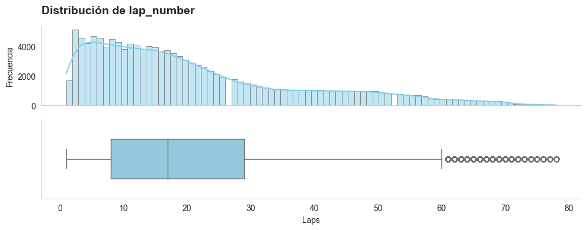

```python
plt.figure(figsize=(10, 4))

# Histograma
plt.subplot(2, 1, 1)
sns.histplot(df_laps['lap_number'], bins=80, color='skyblue', edgecolor='gray', kde=True)
plt.title('Distribución de lap_number', loc='left', fontsize=14, fontweight='bold', pad=15)
plt.xlabel('')
plt.xticks([])
plt.ylabel('Frecuencia')
plt.grid(False)
sns.despine(top=True)

# Boxplot
plt.subplot(2, 1, 2)
sns.boxplot(x=df_laps['lap_number'], color='skyblue', width=0.5)
plt.xlabel('Laps')
plt.ylabel('')
plt.grid(False)
sns.despine(top=True)

plt.tight_layout()
plt.show()
```

Existen outliers a partir de las 60 vueltas; es decir, resulta muy inusual observar más de 60 vueltas en una sesión. Esto se debe a que actualmente no estamos diferenciando por tipo de sesión.

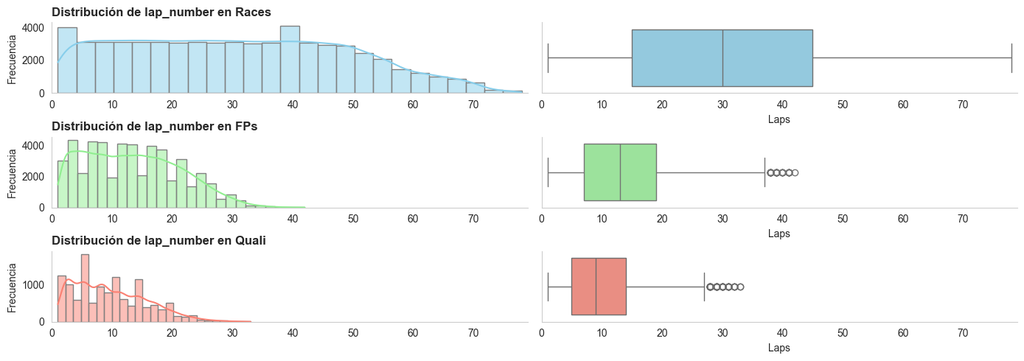

```python
fig, axes = plt.subplots(3, 2, figsize=(14, 5))

session_types = [
    ('R', 'Races', 'skyblue'),
    (['FP1', 'FP2', 'FP3'], 'FPs', 'lightgreen'),
    ('Q', 'Quali', 'salmon')
]

for i, (stype, title, color) in enumerate(session_types):
    data = df_laps
    if isinstance(stype, list):
        data = data[data['session_type_short'].isin(stype)]
    else:
        data = data[data['session_type_short'] == stype]

    # Histograma
    sns.histplot(data['lap_number'], bins=25, color=color, edgecolor='gray', kde=True, ax=axes[i, 0])
    axes[i, 0].set_title(f'Distribución de lap_number en {title}', loc='left', fontsize=12, fontweight='bold')
    axes[i, 0].set_xlabel('')
    axes[i, 0].set_ylabel('Frecuencia')
    axes[i, 0].grid(False)
    sns.despine(ax=axes[i, 0], top=True)

    # Boxplot
    sns.boxplot(x=data['lap_number'], color=color, ax=axes[i, 1])
    axes[i, 1].set_xlabel('Laps')
    axes[i, 1].set_ylabel('')
    axes[i, 1].grid(False)
    sns.despine(ax=axes[i, 1], top=True)

    # Unifica el rango del eje x para todos los subplots
    axes[i, 0].set_xlim(df_laps['lap_number'].min() - 1, df_laps['lap_number'].max() + 1)
    axes[i, 1].set_xlim(df_laps['lap_number'].min() - 1, df_laps['lap_number'].max() + 1)

plt.tight_layout()
plt.show()
```

### ▶️ stint

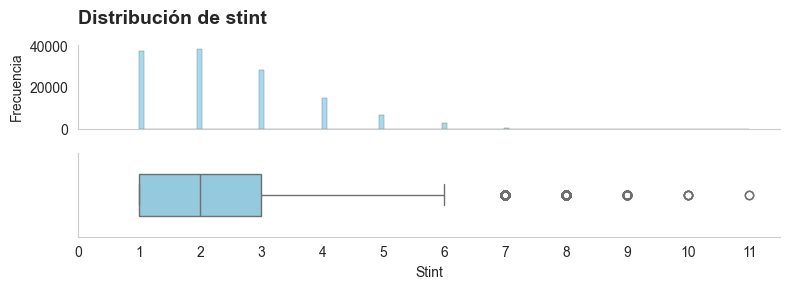

```python
plt.figure(figsize=(8, 3))

# Histograma
plt.subplot(2, 1, 1)
sns.histplot(df_laps['stint'], color='skyblue', edgecolor='gray', kde=False)
plt.title('Distribución de stint', loc='left', fontsize=14, fontweight='bold', pad=15)
plt.xlabel('')
# plt.xticks([])
plt.xticks(range(0, int(df_laps['stint'].max()) + 1, 1), labels=[])
plt.ylabel('Frecuencia')
plt.grid(False)
sns.despine(top=True)

# Boxplot
plt.subplot(2, 1, 2)
sns.boxplot(x=df_laps['stint'], color='skyblue', width=0.5)
plt.xlabel('Stint')
plt.ylabel('')
plt.grid(False)
plt.xticks(range(0, int(df_laps['stint'].max()) + 1, 1))
sns.despine(top=True)

plt.tight_layout()
plt.show()
```

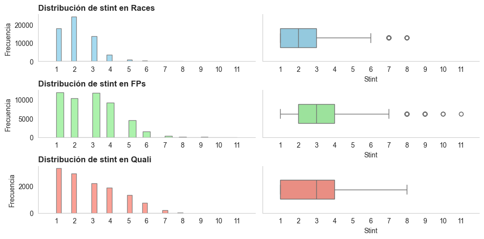

```python
fig, axes = plt.subplots(3, 2, figsize=(10, 5))

session_types = [
    ('R', 'Races', 'skyblue'),
    (['FP1', 'FP2', 'FP3'], 'FPs', 'lightgreen'),
    ('Q', 'Quali', 'salmon')
]

for i, (stype, title, color) in enumerate(session_types):
    data = df_laps
    if isinstance(stype, list):
        data = data[data['session_type_short'].isin(stype)]
    else:
        data = data[data['session_type_short'] == stype]

    # Histograma
    sns.histplot(data['stint'], bins=25, color=color, edgecolor='gray', kde=False, ax=axes[i, 0])
    axes[i, 0].set_title(f'Distribución de stint en {title}', loc='left', fontsize=12, fontweight='bold')
    axes[i, 0].set_xlabel('')
    axes[i, 0].set_ylabel('Frecuencia')
    axes[i, 0].grid(False)
    sns.despine(ax=axes[i, 0], top=True)
    axes[i, 0].set_xticks(range(int(df_laps['stint'].min()), int(df_laps['stint'].max()) + 1, 1))

    # Boxplot
    sns.boxplot(x=data['stint'], color=color, ax=axes[i, 1], width=0.4)
    axes[i, 1].set_xlabel('Stint')
    axes[i, 1].set_ylabel('')
    axes[i, 1].grid(False)
    sns.despine(ax=axes[i, 1], top=True)
    axes[i, 1].set_xticks(range(int(df_laps['stint'].min()), int(df_laps['stint'].max()) + 1, 1))

    # Unifica el rango del eje x para todos los subplots
    axes[i, 0].set_xlim(df_laps['stint'].min() - 1, df_laps['stint'].max() + 1)
    axes[i, 1].set_xlim(df_laps['stint'].min() - 1, df_laps['stint'].max() + 1)

plt.tight_layout()
plt.show()
```

Es interesante cómo en carrera hay menos stint 1 que 2, esto se explica probablemente porque muchos pilotos realizan su primera parada en boxes antes de completar la mitad de la carrera. De esta manera, el stint 1 suele ser más corto y, tras la primera parada, la mayoría de las vueltas se agrupan en el stint 2. Además, si hay abandonos o incidentes en las primeras vueltas, algunos pilotos ni siquiera completan un stint 1 completo, mientras que todos los que continúan en carrera necesariamente pasan por el stint 2. Por eso, la cantidad de vueltas en stint 2 puede superar a la de stint 1 en las carreras.

# PROCESSED

```python
# 1. Cargar datos
df_laps = pd.read_csv('../data/laps_since_2023_raw.csv')
df_laps.columns = ['time', 'driver', 'lap_time', 'lap_number', 'stint', 'compound', 'event_name_region', 'event_date', 'session_type_short', 'year']

# 2. Eliminar filas con valores nulos en 'lap_time', 'stint' o 'compound'
df_laps = df_laps[~df_laps['lap_time'].isna()]
df_laps.dropna(subset=['stint', 'compound'], inplace=True)
df_laps.reset_index(drop=True, inplace=True)

# 3. Conversión de tipos de datos
df_laps['time'] = pd.to_timedelta(df_laps['time'])
df_laps['lap_time'] = pd.to_timedelta(df_laps['lap_time'])
df_laps['event_date'] = pd.to_datetime(df_laps['event_date'])
df_laps['lap_number'] = df_laps['lap_number'].astype('int32')
df_laps['stint'] = df_laps['stint'].astype('int32')
df_laps['year'] = df_laps['year'].astype('int32')

# 4. Crear columnas auxiliares
df_laps['time_minutes'] = df_laps['time'].dt.total_seconds() // 60
df_laps['lap_time_seconds'] = df_laps['lap_time'].dt.total_seconds()

# 5. Detección de outliers en lap_time_seconds usando IQR
Q1 = df_laps['lap_time_seconds'].quantile(0.25)
Q3 = df_laps['lap_time_seconds'].quantile(0.75)
IQR = Q3 - Q1
upper_bound = Q3 + 1.5 * IQR
df_laps['flag_lap_time_outlier'] = df_laps['lap_time_seconds'] > upper_bound

# 6. Normalización de lap_time_seconds por año, evento y tipo de sesión
df_laps['lap_time_seconds_normalized'] = (
    df_laps.groupby(['year', 'event_name_region', 'session_type_short'])['lap_time_seconds']
    .transform(lambda x: MinMaxScaler().fit_transform(x.values.reshape(-1, 1)).flatten())
)

# Reordenar las columnas para una presentación más lógica
cols_order = [
    'year', 'event_name_region', 'event_date', 'session_type_short', 'driver',
    'lap_number', 'stint', 'compound', 'time', 'time_minutes',
    'lap_time', 'lap_time_seconds', 'lap_time_seconds_normalized', 'flag_lap_time_outlier'
]
# Solo mantener las columnas que existen en el dataframe
cols_order = [col for col in cols_order if col in df_laps.columns]
df_laps = df_laps[cols_order]

df_laps.head()
```

|  | year | event_name_region | event_date | session_type_short | driver | lap_number | stint | compound | time | time_minutes | lap_time | lap_time_seconds | lap_time_seconds_normalized | flag_lap_time_outlier |
| --- | --- | --- | --- | --- | --- | --- | --- | --- | --- | --- | --- | --- | --- | --- |
| 0 | 2023 | Bahrain | 2023-03-05 | FP1 | VER | 2 | 1 | MEDIUM | 0 days 00:22:49.992000 | 22.0 | 0 days 00:01:35.429000 | 95.429 | 0.046858 | False |
| 1 | 2023 | Bahrain | 2023-03-05 | FP1 | VER | 5 | 2 | MEDIUM | 0 days 00:30:13.359000 | 30.0 | 0 days 00:01:53.662000 | 113.662 | 0.366724 | False |
| 2 | 2023 | Bahrain | 2023-03-05 | FP1 | VER | 7 | 3 | SOFT | 0 days 00:44:47.890000 | 44.0 | 0 days 00:01:33.375000 | 93.375 | 0.010824 | False |
| 3 | 2023 | Bahrain | 2023-03-05 | FP1 | VER | 8 | 3 | SOFT | 0 days 00:46:56.572000 | 46.0 | 0 days 00:02:08.682000 | 128.682 | 0.630224 | False |
| 4 | 2023 | Bahrain | 2023-03-05 | FP1 | VER | 10 | 4 | SOFT | 0 days 01:01:19.967000 | 61.0 | 0 days 00:01:37.900000 | 97.900 | 0.090207 | False |

```python
df_laps.to_parquet('../data/laps_since_2023_processed.parquet', index=False)
```

Se exporta en formato Parquet para conservar los tipos de datos originales de cada columna.